# Multinomial Regression using a Binomial Classifier

### 1.0 Synopsis

Use the ‘hepatic’ dataset of the AppliedPredictiveModeling library to demonstrate how to perform a One-vs-All multinomial logistic regression using a binomial classifier. Evaluate a knn classifier and find the optimum value of k that yields the highest accuracy.

### 2.0 Data Exploration, Preprocessing and Partitioning

Load libraries and hepatic data

```r
library(AppliedPredictiveModeling)
library(caret)
library(glmnet)
library(class)
library(kernlab)
data(hepatic)
```

Check data for missing values. Check need for normalization. Review dataset structure.

```r
#Explore 'bio' data
#any(is.na(bio)) # check missing values: no missing values
#apply(bio, 2, var) # check need for standardization: low variance, standardization not needed
#str(bio)
#str(injury)
table(injury)/length(injury) #check distribution of response variables
```

```
injury
     Mild      None    Severe
0.5160142 0.3772242 0.1067616
```

Injury levels (response variable) are unevenly distributed. Therefore, choose stratified sampling by injury as the data partitioning strategy

```r
set.seed(120)
training_rows <- createDataPartition(injury, p=0.75, list = FALSE)
training_predictors <- bio[training_rows,]
training_responses <- injury[training_rows]
test_predictors <- bio[-training_rows,]
test_responses <- injury[-training_rows]
```

### 3.0 One-versus-All Logistic Model

##### 3.1 Model 1: Mild = 1

Classify Mild as 1 and the remaining levels as 0

```r
Mild.training_responses <- as.factor(ifelse(training_responses == "Mild", 1, 0))
```

Train the model and predict fitted probabilities

```r
TrainXy <- cbind(training_predictors, Mild.training_responses)
colnames(TrainXy)[185] <- "y"
log.Mild <- glm(formula = y ~ ., data = TrainXy, family = binomial())
#summary(log.Mild)
Mild.fitted.probs <- predict(log.Mild, newdata = test_predictors, type = "response")
```

##### 3.2 Model 2: None = 1

Classify None as 1 and the remaining levels as 0

```r
None.training_responses <- as.factor(ifelse(training_responses == "None", 1, 0))
```

Train model and predict fitted probabilities

```r
TrainXy <- cbind(training_predictors, None.training_responses)
colnames(TrainXy)[185] <- "y"
log.None <- glm(formula = y ~ ., data = TrainXy, family = binomial())
#summary(log.None)
None.fitted.probs <- predict(log.None, newdata = test_predictors, type = "response")
```

##### 3.3 Model 3: Severe = 1

Classify Severe as 1 and the remaining levels as 0

```r
Severe.training_responses <- as.factor(ifelse(training_responses == "Severe", 1, 0))
```

Train model and predict fitted probabilities

```r
TrainXy <- cbind(training_predictors, Severe.training_responses)
colnames(TrainXy)[185] <- "y"
log.Severe <- glm(formula = y ~ ., data = TrainXy, family = binomial())
#summary(log.Severe)
Severe.fitted.probs <- predict(log.Severe, newdata = test_predictors, type = "response")
```

##### 3.4 Assign final model predictions

Each of the 3 models above assigns the observations a probability score for each of the responses - Severe, None or Mild. From among three probability scores, assign the one that has the highest probability score versus all the others, to the observation. This will serve as the final predicted response for each observation.

```r
model.probs <- data.frame(cbind(Mild.fitted.probs, None.fitted.probs, Severe.fitted.probs))
colnames(model.probs) <- c("Mild", "None", "Severe")
model.predictions <- as.factor(colnames(model.probs)[apply(model.probs, 1, which.max)])
```

##### 3.5 Logistic one-versus-all model evaluation

```r
table(model.predictions, test_responses) #confusion matrix
```

```
                 test_responses
model.predictions Mild None Severe
           Mild     22   12      3
           None     11   11      2
           Severe    3    3      2
```

```r
log.misClassError = mean(model.predictions != test_responses) # error rate
print(paste("Logistic one-vs-all Accuracy = ", 1-log.misClassError )) #accuracy
```

```
[1] "Logistic one-vs-all Accuracy =  0.507246376811594"
```

### 4.0 K-nearest Neigbour

Compute knn accuracies for k.values = 1:20

```r
k.values <- 1:20
knn.Accuracy <- NULL
for(i in k.values) {
  set.seed(125)
  knn.responses <- knn(training_predictors, test_predictors, training_responses, k = i)
  knn.misClassError <- mean(test_responses != knn.responses)
  knn.Accuracy[i] <- 1 - knn.misClassError
}
```

Plot graph to identify max accuracy and optimal K value

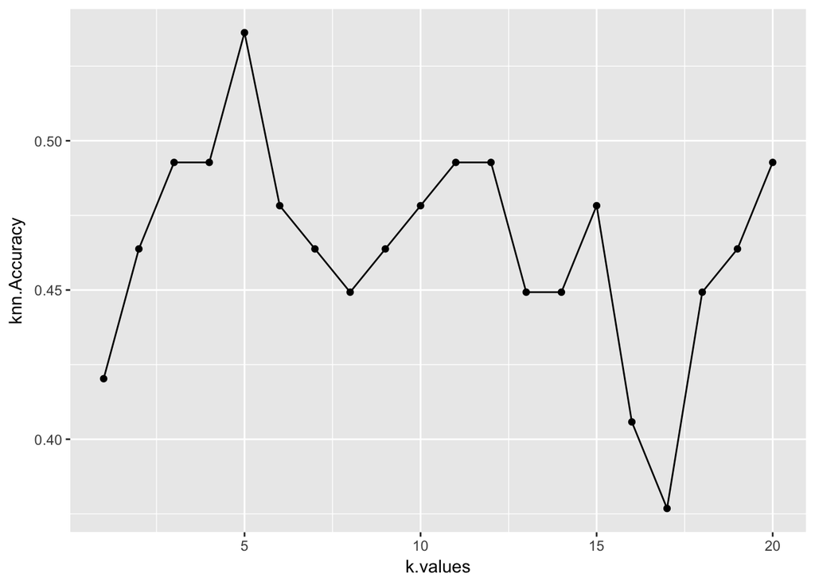

```r
elbowdf <- data.frame(k.values, knn.Accuracy)
ggplot(elbowdf, aes(x = k.values, y = knn.Accuracy)) + geom_point() + geom_line()
```

Choose the optimum K value using the highest accuracy

```r
print(paste("Optimum K value = ",which(knn.Accuracy == max(knn.Accuracy), arr.ind = TRUE)))
```

```
[1] "Optimum K value =  5"
```

```r
print(paste("knn.Accuracy = ", max(knn.Accuracy)))
```

```
[1] "knn.Accuracy =  0.536231884057971"
```